# Australian Football League: How to win

## Analysis: Visualising indices (pg.3 of 6)

Indices by year, showing median, IQR and range (Red/LHS = loss, Blue/RHS = win), corresponding mosaic plot coloured by Chi-squared residual:

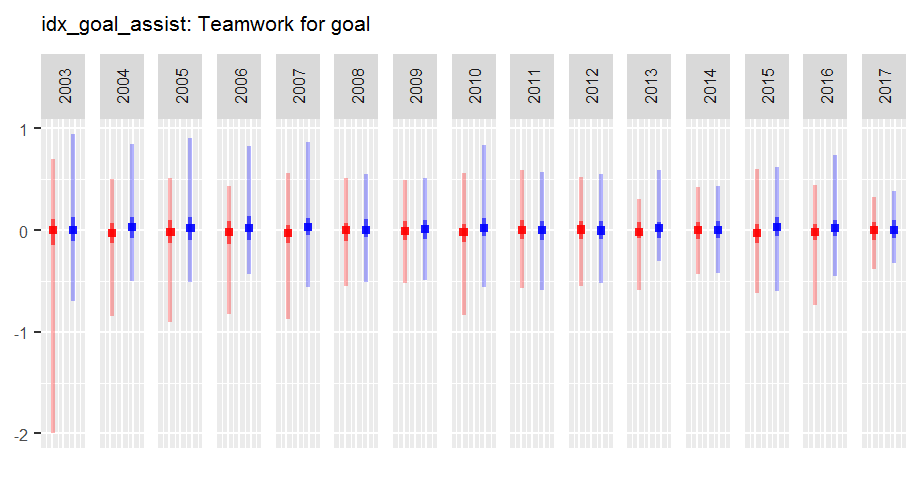

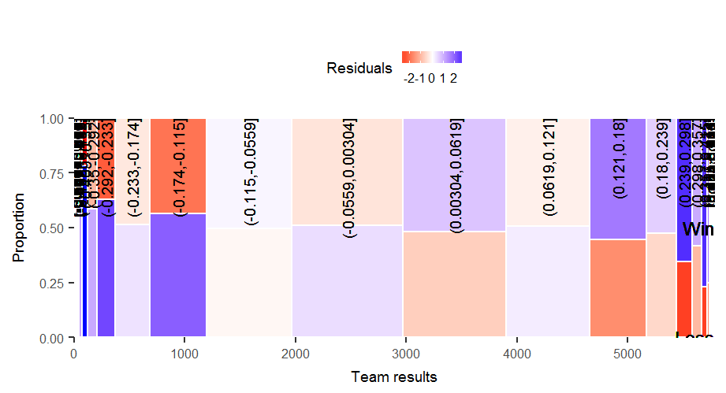

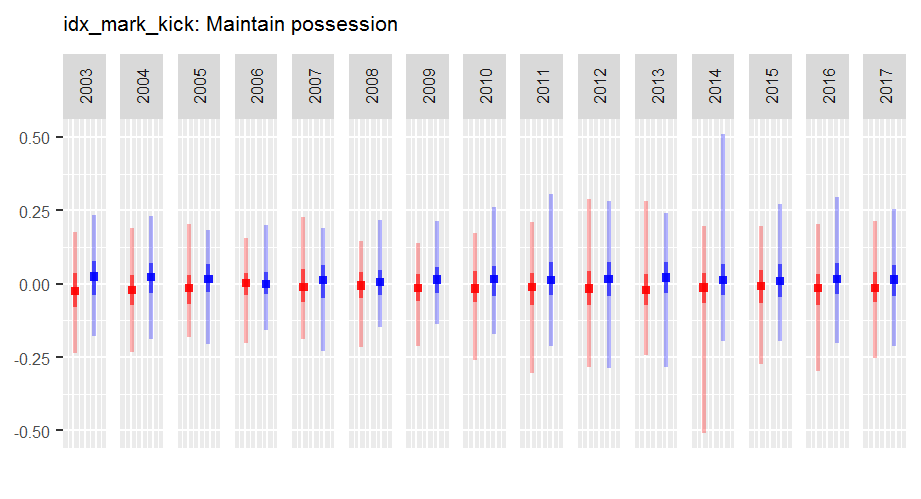

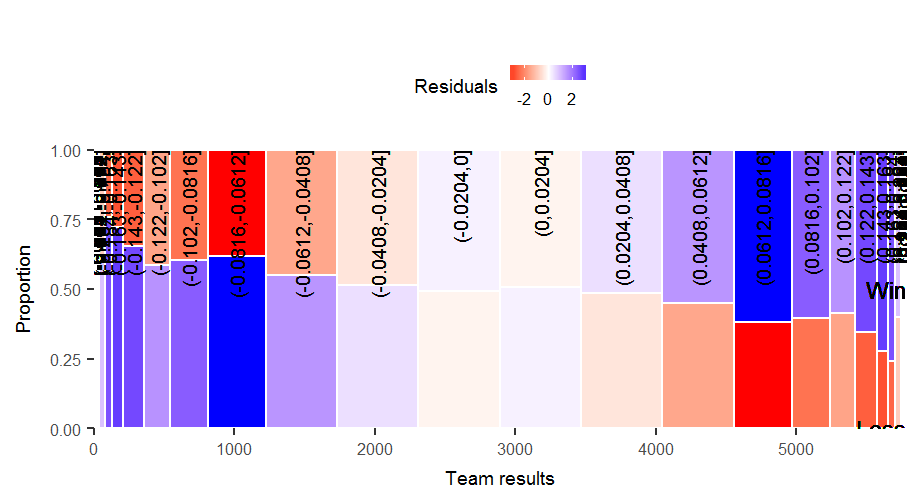

## Analysis: Visualising indices (pg.4 of 6)

Indices by year, showing median, IQR and range (Red/LHS = loss, Blue/RHS = win), corresponding mosaic plot coloured by Chi-squared residual:

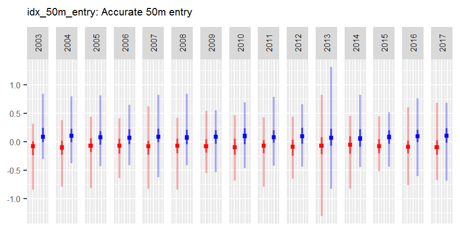

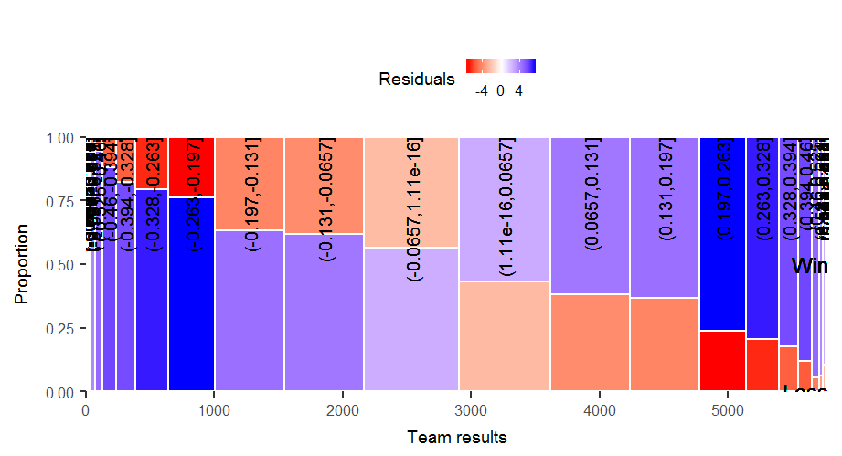

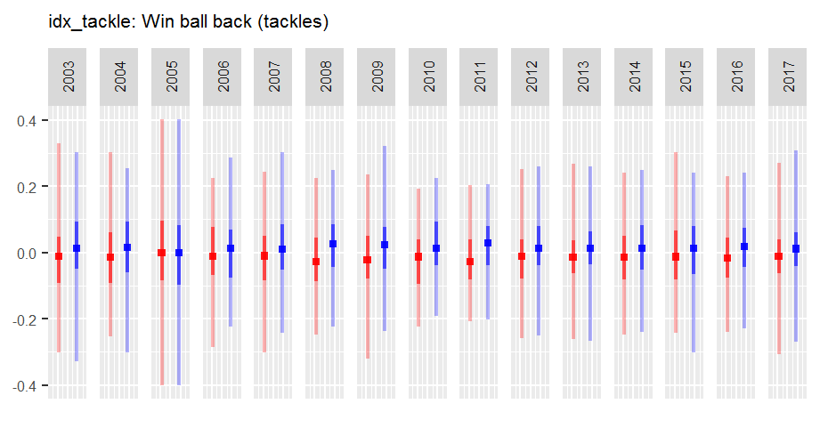

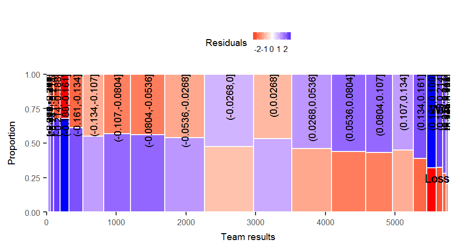

## Analysis: Visualising indices (pg.5 of 6)

Indices by year, showing median, IQR and range (Red/LHS = loss, Blue/RHS = win), corresponding mosaic plot coloured by Chi-squared residual:

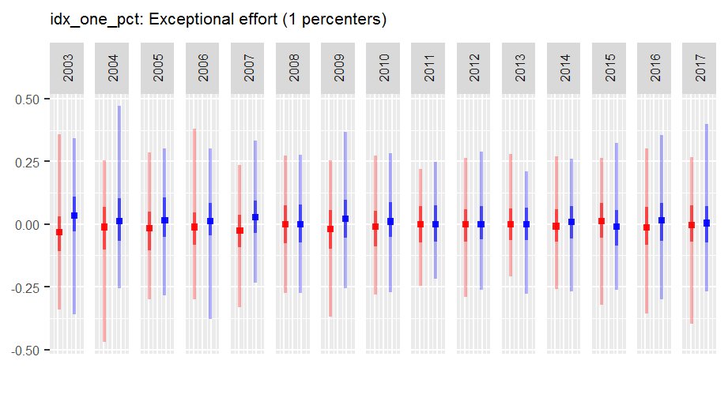

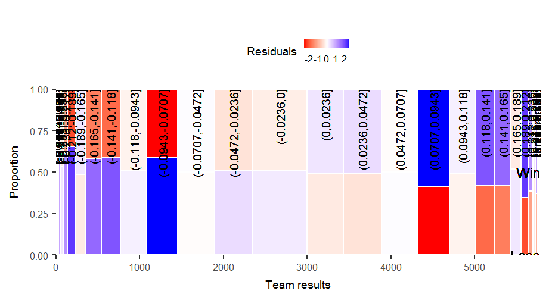

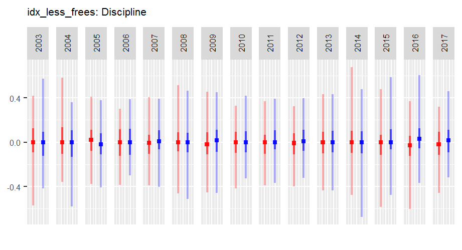

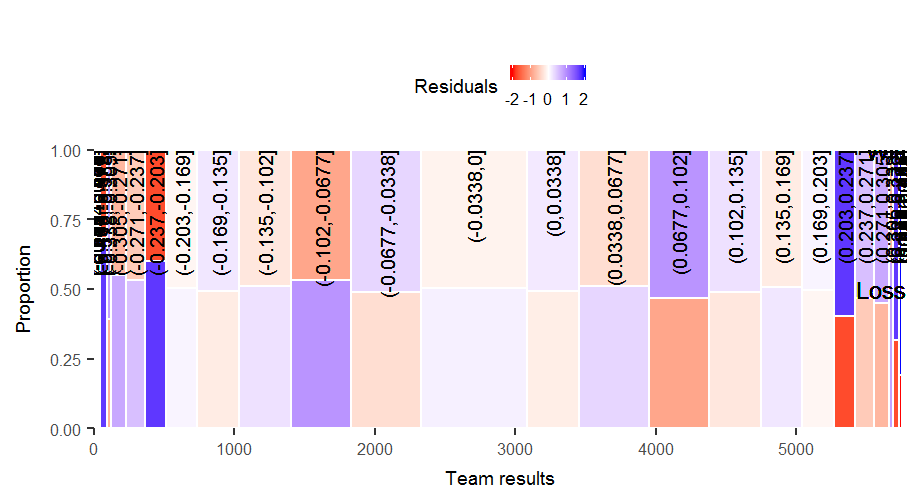

## Analysis: Visualising indices (pg.6 of 6)

Finally, to check the distributions of the index data, I created a histogram function (Red/LHS = loss, Blue/RHS = win):

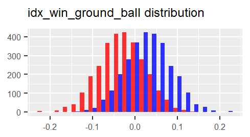

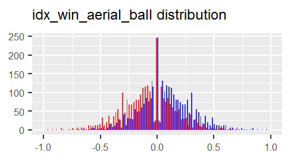

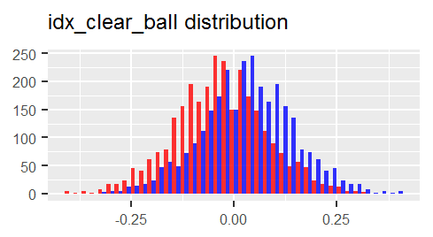

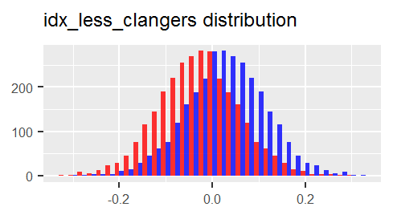

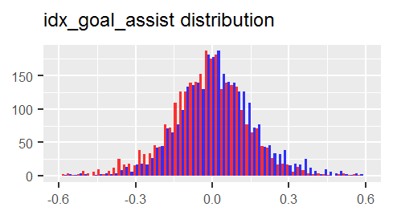

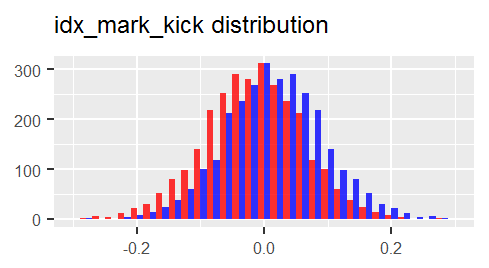

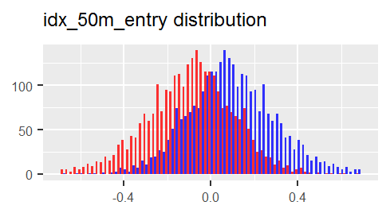

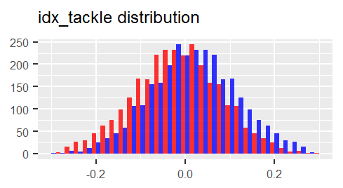

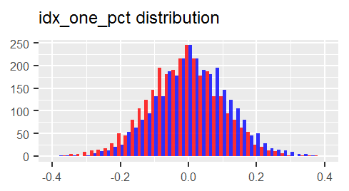

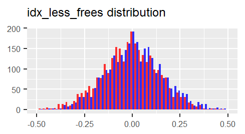

```r
ggplot_hist = function(in_df, xvar, in_width, plot_title){
  ggph = ggplot(in_df, aes(x=in_df[[xvar]], fill=team_result)) + geom_histogram(binwidth = in_width, position = position_dodge(in_width), alpha=0.8) +
            scale_fill_manual(labels = c("Loss","Win"), values = c("red","blue")) + labs(title = plot_title, color = "Result") +
            theme(axis.title.x = element_blank(), axis.title.y = element_blank(), axis.text.x = element_text(size = 6),
                  axis.text.y = element_text(size = 6), legend.position = "none", plot.title = element_text(size = 9))
  return(ggph) }
```

## Analysis: Statistics of index relationships

I ran two statistical tests on each "interesting" index seeking a relationship to wins: 1) re-randomization of results and 2) significance test.

### Re-randomization: idx_win_ground_ball

I re-randomized the win/loss results of the data 1000 times (commented code was run and results saved).

```r
# AFL.by.match.idx.random = AFL.by.match.idx %>% select(team_result, starts_with("idx_")) %>% mutate(team_result = sample(0:1, nrow(AFL.by.match.idx.random), replace = TRUE))
# AFL.by.match.idx.random.res = AFL.by.match.idx.random %>% group_by(team_result) %>%  summarise_all(funs(mean))
# for(i in 2:1000){ AFL.by.match.idx.random$team_result = sample(0:1, nrow(AFL.by.match.idx.random), replace = TRUE)
#                   AFL.by.match.idx.random.res = rbind(AFL.by.match.idx.random.res, AFL.by.match.idx.random %>% group_by(team_result) %>% summarise_all(funs(mean))) }
load(file = ".\\AFL_by_match_idx_random_res.Rda")
Xbar <- AFL.by.match.idx %>% select(team_result, starts_with("idx_")) %>% group_by(team_result) %>% summarise(mean(idx_win_ground_ball))
print(as.list(AFL.by.match.idx.random.res %>% filter(team_result == 1 & (idx_win_ground_ball <= Xbar[[2]][[1]] | idx_win_ground_ball >= Xbar[[2]][[2]])) %>% count()))
```

```
## $n
## [1] 0
```

There were zero re-randomisations with a mean equal to or greater than the mean of idx_win_ground_ball for Wins, so the first test indicates the result is **not random**.

### Significance test: idx_win_ground_ball

```r
  print(as.data.frame(AFL.by.match.idx %>% group_by(team_result) %>% summarise(mean(idx_win_ground_ball), sd(idx_win_ground_ball), n())))
```

```
##   team_result mean(idx_win_ground_ball) sd(idx_win_ground_ball)  n()
## 1           0               -0.02814632              0.05430982 2891
## 2           1                0.02814632              0.05430982 2891
```

We assume the probability of winning any match is random (0.5). Null hypothesis: idx_win_ground_ball has no impact to the match result so its true mean is 0; \(H_0:\mu=0\). Let X be the random variable idx_win_ground_ball in Wins.

Assuming \(\sigma=s=0.054310\), \(z_\bar{X} = (0.028146-\mu)/\sigma = (0.028146-0)/0.054310 = 0.52\) This z-score corresponds to a probability of 0.6985 so the team leading idx_win_ground_ball in an AFL match should win approximately 70% of the time **(Strong relationship)**.

## Analysis: Statistics of index relationships (cont'd)

Performing the same two tests on the remaining indices yielded these results:

| Index | Randomized Means > Idx Mean | Re-randomisation Test Result | Idx Z-score | Significance Test Result |
| --- | --- | --- | --- | --- |
| *idx_win_ground_ball* | *0* | *Index result is not random* | *0.52 (0.6985)* | *The team leading this index should win approx. 70% of the time (Strong)* |
| idx_win_aerial_ball | 0 | Index result is not random | 0.33 (0.6293) | The team leading this index should win approx. 63% of the time **(Fair)** |
| idx_clear_ball | 0 | Index result is not random | 0.27 (0.6064) | The team leading this index should win approx. 61% of the time **(Fair)** |
| idx_less_clangers | 0 | Index result is not random | 0.30 (0.6179) | The team leading this index should win approx. 62% of the time **(Fair)** |
| idx_goal_assist | 0 | Index result is not random | 0.12 (0.5478) | The team leading this index should win approx. 55% of the time **(Weak)** |
| idx_mark_kick | 0 | Index result is not random | 0.19 (0.5753) | The team leading this index should win approx. 58% of the time **(Weak)** |
| idx_50m_entry | 0 | Index result is not random | 0.45 (0.6736) | The team leading this index should win approx. 67% of the time **(Fair)** |
| idx_tackle | 0 | Index result is not random | 0.16 (0.5636) | The team leading this index should win approx. 56% of the time **(Weak)** |
| idx_one_pct | 0 | Index result is not random | 0.10 (0.5398) | The team leading this index should win approx. 54% of the time **(Weak)** |
| idx_less_frees | 0 | Index result is not random | 0.06 (0.5239) | The team leading this index should win approx. 52% of the time **(Weak)** |

Interestingly, none of the indices tested as being random but most of them are fairly weak indicators of success if we regard the benchmark as being a 50% win rate.

## Analysis: Selecting indices for Machine Learning

The below correlation matrix shows there are a few metrics with stronger relationships to winning and a few potential multicollinearity pitfalls.

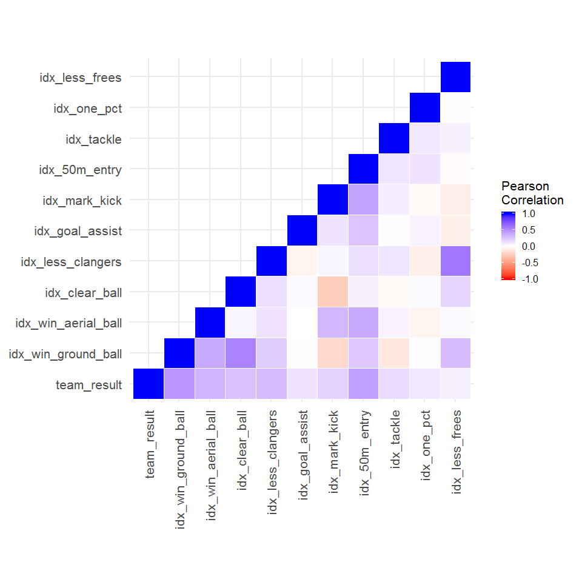

## Analysis: Selecting indices for Machine Learning (cont'd)

The indices with the strongest statistical and visual relationship to wins are:

- idx_win_ground_ball
- idx_win_aerial_ball
- idx_clear_ball
- idx_50m_entry
- idx_less_clangers

I have also included idx_less_frees as it displays some correlation with idx_win_ground_ball and idx_less_clangers.

## Machine Learning

## ML: Feature engineering

### Team proportion of top ten players per match

In order to dive further into the analysis, I took the numerator of each indice and analysed the proportion of the top 10 players in each match belonging to each team; e.g. if 6 of the top 10 ground ball winners were from Team A, then A's score is 0.6 and B's is 0.4. These features will provide an alternative measure when performing decision tree and logistic regression analysis.

This code takes a long time to run so it's commented out here and the saved data frame is loaded. The **setDT** function comes from the **data.table** package.

```r
  # Get individual player metrics for each game
  AFL.by.player.disagg = semi_join(AFL.by.player, AFL.by.match.idx.1, by = c("Team", "Year", "round", "match_id", "team_result")) %>%
    select(match_id, Year:Team, Clangers:Contested_possessions, Frees_against, Inside_50s, Marks_inside_50)
  # Create function to calculate proportion of top 10 for a given metric in a given game
  var.top.n = function(matchid, team.nm, pvar, n = 10){ DF = AFL.by.player.disagg %>% select(match_id, Team, pvar) %>% filter(match_id == matchid) %>% top_n(n)
    prop.top.10 = (DF %>% filter(Team == team.nm) %>% count)/(nrow(DF))
    return(prop.top.10) }
  # Call function for each game
    # AFL.by.player.agg = AFL.by.match.idx.1 %>% ungroup
    # setDT(AFL.by.player.agg)[ , Clangers := var.top.n(match_id, Team, "Clangers", 10), by=c("match_id","Year","round","Team")]
    # setDT(AFL.by.player.agg)[ , Clearances := var.top.n(match_id, Team, "Clearances", 10), by=c("match_id","Year","round","Team")]
    # setDT(AFL.by.player.agg)[ , Contested_marks := var.top.n(match_id, Team, "Contested_marks", 10), by=c("match_id","Year","round","Team")]
    # setDT(AFL.by.player.agg)[ , Contested_possessions := var.top.n(match_id, Team, "Contested_possessions", 10), by=c("match_id","Year","round","Team")]
    # setDT(AFL.by.player.agg)[ , Frees_against := var.top.n(match_id, Team, "Frees_against", 10), by=c("match_id","Year","round","Team")]
    # setDT(AFL.by.player.agg)[ , Inside_50s := var.top.n(match_id, Team, "Inside_50s", 10), by=c("match_id","Year","round","Team")]
    # setDT(AFL.by.player.agg)[ , Marks_inside_50 := var.top.n(match_id, Team, "Marks_inside_50", 10), by=c("match_id","Year","round","Team")]
```

```
##    Year round match_id             Team team_result match_score_idx idx_win_ground_ball idx_win_aerial_ball idx_clear_ball idx_less_clangers idx_goal_assist idx_mark_kick idx_50m_entry  idx_tackle
## 1: 2017   R01     1001          Carlton           0       0.6742424         -0.03330718           0.1047354    -0.02227639       0.050166609     -0.05595141   0.151313374    0.07605987 -0.11344445
## 2: 2017   R01     1001         Richmond           1       1.4831461          0.03330718          -0.1047354     0.02227639      -0.050166609      0.05595141  -0.151313374   -0.07605987  0.11344445
## 3: 2017   R01     1002      Collingwood           0       0.8600000          0.07649211           0.0000000     0.20827594      -0.009759837      0.00000000   0.005457992    0.01782368 -0.11344445
## 4: 2017   R01     1002 Western Bulldogs           1       1.1627907         -0.07649211           0.0000000    -0.20827594       0.009759837      0.00000000  -0.005457992   -0.01782368  0.11344445
## 5: 2017   R01     1003        Melbourne           1       1.3333333          0.02430253           0.0000000     0.15209098      -0.070581074      0.23888209   0.130037988    0.12355469  0.06105397
## 6: 2017   R01     1003         St Kilda           0       0.7500000         -0.02430253           0.0000000    -0.15209098       0.070581074     -0.23888209  -0.130037988   -0.12355469 -0.06105397
##    idx_one_pct idx_less_frees  Clangers Clearances Contested_marks Contested_possessions Frees_against Inside_50s Marks_inside_50
## 1:  0.22184875     0.31875876 0.5833333  0.5714286          0.5000             0.4000000     0.2500000  0.4285714       0.4375000
## 2: -0.22184875    -0.31875876 0.4166667  0.4285714          0.5000             0.6000000     0.7500000  0.5714286       0.5625000
## 3: -0.15892323     0.02632894 0.5714286  0.5000000          0.4375             0.5714286     0.6086957  0.6315789       0.6428571
## 4:  0.15892323    -0.02632894 0.4285714  0.5000000          0.5625             0.4285714     0.3913043  0.3684211       0.3571429
## 5:  0.07169322    -0.12493874 0.5833333  0.6428571          0.5000             0.6923077     0.5416667  0.6666667       0.6000000
## 6: -0.07169322     0.12493874 0.4166667  0.3571429          0.5000             0.3076923     0.4583333  0.3333333       0.4000000
```

## ML: Data preparation

### Splitting the data for baseline model assessment

To create the models, I will train them with all data to the end of 2016 (5,374 records, 2,687 matches), therefore the 2017 season data will form the test set (408 records, 204 matches). Note that this test set includes the player metrics for the matches, which is data we would not normally have when predicting match results in the future.

This data will be used to form a baseline assessment of **how well the indices predict match results generally**, i.e. demonstrating the statistical analysis which proved the relationship between the indices and winning.

```r
  train1 = subset(AFL.by.player.agg, AFL.by.player.agg$Year != 2017)
  test1 = subset(AFL.by.player.agg, AFL.by.player.agg$Year == 2017)
```

## ML: Data preparation (cont'd)

### Preparing realistic test data for prediction assessment

To make predictions more realistic, I will also test the models against 2017 data with all fields redacted except match-up fixtures and which players were on the field. I used player averages from the 2016 season as a proxy for how each individual is expected to perform in 2017 and aggregated these metrics to team level to predict the match results. If a player did not have 2016 averages then there was no prediction of their 2017 performance. This data will be used to form an assessment of **how well the models actually perform at predicting future match outcomes**.

```r
  # Take player data for 2016 (one year), try to predict match results for 2017 based on averages
  AFL.by.player.2016 = AFL.by.player %>% filter(Year %in% 2016) %>% select(-(Year:Team), -Played_pct, -(home_away:match_score_idx)) %>%
    group_by(Player) %>% summarise_all(.funs = mean) %>% select(Player, Contested_marks, Frees_against, Contested_possessions, Clangers, Marks_inside_50, Inside_50s)
  head(data.frame(AFL.by.player.2016), 5)
```

```
##          Player Contested_marks Frees_against Contested_possessions Clangers Marks_inside_50 Inside_50s
## 1  Ablett, Gary       0.0000000     1.3571429             13.214286 3.000000       0.4285714  4.3571429
## 2  Acres, Blake       0.3750000     0.6250000              6.437500 2.125000       0.6250000  2.9375000
## 3 Adams, Marcus       1.4545455     0.6363636              6.181818 1.818182       0.0000000  0.9090909
## 4 Adams, Taylor       0.0000000     1.0714286             10.571429 3.357143       0.0000000  3.6428571
## 5   Adcock, Jed       0.1428571     0.8571429              3.285714 1.571429       0.1428571  2.0000000
```

```r
  # Prepare 2017 predicted data
  AFL.matches.2017.pred = AFL.by.player %>% filter(Year == 2017) %>% select(match_id, round, Team, vs_opponent, Player, team_result) %>% inner_join(AFL.by.player.2016, by = "Player")
    # As before, take a team-wise view by summing up the player averages
    AFL.matches.2017.pred.sum = AFL.matches.2017.pred %>% group_by(match_id, round, Team, vs_opponent, team_result) %>% summarise_at(vars(Contested_marks:Inside_50s), .funs = sum)
    # Function to get proportion of top 10 players for Inside_50s, each team
    i50.top.n <- function(matchid, team.nm, n = 10){ DF <- AFL.matches.2017.pred %>% select(match_id, Team, "Inside_50s") %>% filter(match_id == matchid) %>% top_n(n)
      prop.top.10 <- (DF %>% filter(Team == team.nm) %>% count)/(nrow(DF))
      return(prop.top.10) }
    setDT(AFL.matches.2017.pred.sum)[ , Inside_50s_prop := i50.top.n(match_id, Team, 10), by=c("match_id","round","Team")]
    # Prepare indices as per previous
    AFL.matches.2017.pred.sum.1 = merge(AFL.matches.2017.pred.sum, AFL.matches.2017.pred.sum %>% rename(Team.opp=Team), by.x=c("match_id","round","Team"), by.y=c("match_id","round","vs_opponent"),
      suffix=c("",".opp")) %>% mutate(idx_win_ground_ball = log10(Contested_possessions/Contested_possessions.opp), idx_win_aerial_ball = log10(Contested_marks/Contested_marks.opp),
      idx_less_clangers = log10(Clangers.opp/Clangers), idx_50m_entry = log10((Marks_inside_50/Inside_50s)/(Marks_inside_50.opp/Inside_50s.opp)),
      idx_less_frees = log10(Frees_against.opp/Frees_against)) %>% select(match_id:team_result, starts_with("idx_"), Inside_50s = Inside_50s_prop)
```

```
##   match_id round             Team      vs_opponent team_result idx_win_ground_ball idx_win_aerial_ball idx_less_clangers idx_50m_entry idx_less_frees Inside_50s
## 1     1001   R01          Carlton         Richmond           0        -0.098047339         -0.06554736        0.10455363  -0.009627112      0.1201273        0.4
## 2     1001   R01         Richmond          Carlton           1         0.098047339          0.06554736       -0.10455363   0.009627112     -0.1201273        0.6
## 3     1002   R01      Collingwood Western Bulldogs           0         0.001459716          0.07143388       -0.04986129   0.161991469     -0.1679122        0.4
## 4     1002   R01 Western Bulldogs      Collingwood           1        -0.001459716         -0.07143388        0.04986129  -0.161991469      0.1679122        0.6
```

## ML: Data preparation (cont'd)

### Clustering data for boosted prediction

To boost the predictive accuracy of the models, I used k-means clustering to consider games with "similar attributes" together. I chose six clusters, representing teams finishing at the top, middle and bottom of the ladder, and moving the ball either quickly or slowly (3x2). The code below requires the R package **flexclust**.

```r
  # create matrices for training and test data, since clustering requires numerical data
  train1_Matrix = as.matrix(train1 %>% select(idx_win_ground_ball, idx_win_aerial_ball, idx_less_clangers, idx_50m_entry, idx_less_frees, Inside_50s))
  AFL.matches.2017.pred.sum.1_Matrix = as.matrix(AFL.matches.2017.pred.sum.1 %>% select(idx_win_ground_ball:Inside_50s))

  # cluster the training set
  k=6
  set.seed(1)
  train1_kmc = kmeans(train1_Matrix, centers = k, iter.max = 10000)
  train1_clusters = train1_kmc$cluster

  # apply the training clustering algorithm to the test data
  train1_kcca = as.kcca(train1_kmc, train1_Matrix)
  AFL.matches.2017.pred.sum.1_clusters = predict(train1_kcca, newdata = AFL.matches.2017.pred.sum.1_Matrix)

  # split out the data sets
  train1_clust1 = subset(train1, train1_clusters==1)
  train1_clust2 = subset(train1, train1_clusters==2)
  train1_clust3 = subset(train1, train1_clusters==3)
  train1_clust4 = subset(train1, train1_clusters==4)
  train1_clust5 = subset(train1, train1_clusters==5)
  train1_clust6 = subset(train1, train1_clusters==6)
  pred2017_clust1 = subset(AFL.matches.2017.pred.sum.1, AFL.matches.2017.pred.sum.1_clusters==1)
  pred2017_clust2 = subset(AFL.matches.2017.pred.sum.1, AFL.matches.2017.pred.sum.1_clusters==2)
  pred2017_clust3 = subset(AFL.matches.2017.pred.sum.1, AFL.matches.2017.pred.sum.1_clusters==3)
  pred2017_clust4 = subset(AFL.matches.2017.pred.sum.1, AFL.matches.2017.pred.sum.1_clusters==4)
  pred2017_clust5 = subset(AFL.matches.2017.pred.sum.1, AFL.matches.2017.pred.sum.1_clusters==5)
  pred2017_clust6 = subset(AFL.matches.2017.pred.sum.1, AFL.matches.2017.pred.sum.1_clusters==6)
```

## ML: Model 1 - Basic Decision Tree

### Creating a basic decision tree

Predicting a win or loss is a classification problem so a decision tree is an obvious method to try. Here is a first-cut tree with bucket size of 25. The **rpart**, **rpart.plot** and **ROCR** libraries are loaded.

```r
  tree1 = rpart(team_result ~ idx_win_ground_ball + idx_win_aerial_ball + idx_clear_ball + idx_less_clangers + idx_50m_entry + idx_less_frees + Clangers + Clearances + Contested_marks + Contested_possessions + Frees_against + Inside_50s + Marks_inside_50,
                data = train1, method = "class", control = rpart.control(minbucket=25))
  prp(tree1, extra = 1, fallen.leaves = TRUE, varlen = 0)
```

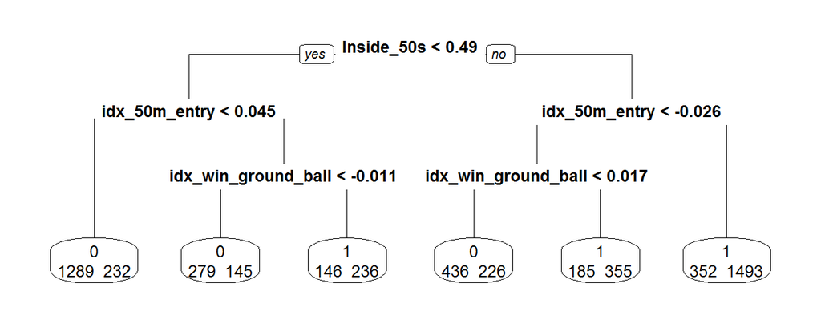

```r
  # only keep variables shown on tree
  tree1_V2 = rpart(team_result ~ idx_win_ground_ball + idx_50m_entry + Inside_50s,
                   data = train1, method = "class", control = rpart.control(minbucket=25))
```

## ML: Model 1 - Basic Decision Tree (cont'd)

### Model baseline assessment

Using a decision tree based on match indices, how well does the model predict 2017's match results (classification accuracy and area under the ROC curve [AUC])? Note that this test data includes the 2017 player metrics so it is not a "true" prediction.

```r
  table(test1$team_result, predict(tree1_V2, newdata = test1, type = "class"))
```

```
##
##       0   1
##   0 159  45
##   1  50 154
```

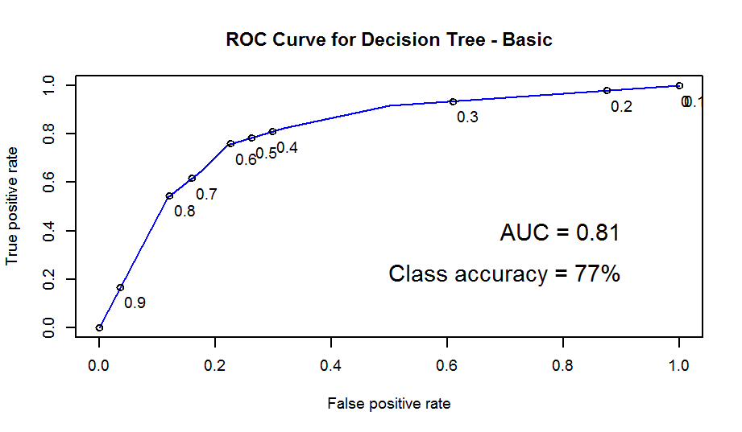

```r
  pred_tree1ROC = predict(tree1, newdata = test1) # note: changing threshold did not improve results
  pred_tree1R = prediction(pred_tree1ROC[ ,2], test1$team_result)
  perf_tree1R = performance(pred_tree1R, "tpr", "fpr")
    par(cex = 0.6)
    plot(perf_tree1R, col="blue", main="ROC Curve for Decision Tree - Basic", print.cutoffs.at = seq(0, 1, 0.1), text.adj = c(-0.2, 1.7))
    text(0.9, 0.4, labels = paste("AUC = ", round(as.numeric(performance(pred_tree1R, "auc")@y.values),2),sep=""), adj=1, cex = 1.5)
    text(0.9, 0.22, labels = paste("Class accuracy = ", round((159+154)/408,2)*100, "%", sep=""), adj=1, cex = 1.5)
```

## ML: Model 1 - Basic Decision Tree (cont'd)

### Model prediction assessment

The basic decision tree was not great at predicting 2017 match results (when the player metrics were also predicted using 2016 averages). It achieved a classification (win/not win) accuracy of 61% and AUC of 0.59.

```r
  pred_tree1_2017 = predict(tree1_V2, newdata = AFL.matches.2017.pred.sum.1, type = "class")
  table(AFL.matches.2017.pred.sum.1$team_result, pred_tree1_2017)
```

```
##    pred_tree1_2017
##       0   1
##   0 112  98
##   1  65 139
```

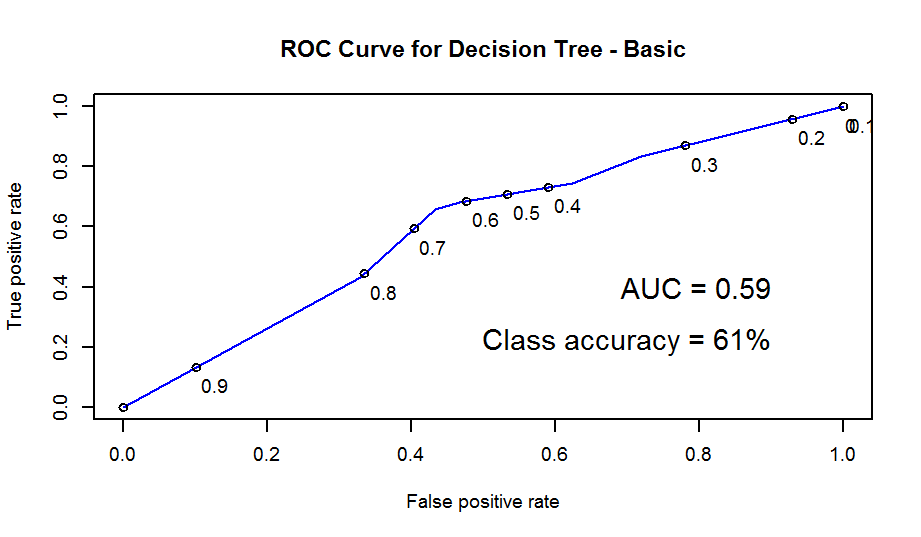

```r
  pred_tree1_2017pr = predict(tree1_V2, newdata = AFL.matches.2017.pred.sum.1)
  pred_tree1_2017ROC = prediction(pred_tree1_2017pr[ ,2], AFL.matches.2017.pred.sum.1$team_result)
  perf_tree1_2017ROC = performance(pred_tree1_2017ROC, "tpr", "fpr")
    par(cex = 0.6)
    plot(perf_tree1_2017ROC, col="blue", main="ROC Curve for Decision Tree - Basic", print.cutoffs.at = seq(0, 1, 0.1), text.adj = c(-0.2, 1.7))
    text(0.9, 0.4, labels = paste("AUC = ", round(as.numeric(performance(pred_tree1_2017ROC, "auc")@y.values),2),sep=""), adj=1, cex = 1.5)
    text(0.9, 0.22, labels = paste("Class accuracy = ", round((112+139)/414,2)*100, "%", sep=""), adj=1, cex = 1.5)
```

## ML: Model 2 - Tuned Decision Tree

### Tuning to create a better tree

I performed cross-validation of the tree to find the right complexity parameter (cp), which returned a value of 0.0022. This is used instead of min bucket size, which is often a blind guess when tuning a decision tree.

```r
  fitControl = trainControl(method = "cv", number = 10)
  cpGrid = expand.grid(.cp=(1:50)*0.0001)
  train(team_result ~ idx_win_ground_ball + idx_win_aerial_ball + idx_clear_ball + idx_less_clangers + idx_50m_entry + idx_less_frees + Clangers + Clearances + Contested_marks + Contested_possessions + Frees_against + Inside_50s + Marks_inside_50,
        data = train1, method = "rpart", trControl = fitControl, tuneGrid = cpGrid)
```

However, this cp produced too many levels in the tree to be meaningfully translated into insights so instead I used cp = 0.005. I then reduced the tree to only those variables which split the nodes.

```r
  tree2 = rpart(team_result ~ idx_win_ground_ball + idx_win_aerial_ball + idx_clear_ball + idx_less_clangers + idx_50m_entry + idx_less_frees + Clangers + Clearances + Contested_marks + Contested_possessions + Frees_against + Inside_50s + Marks_inside_50,
                data = train1, method = "class", control = rpart.control(cp = 0.005))
  tree2_V2 = rpart(team_result ~ idx_win_ground_ball + idx_less_clangers + idx_50m_entry + Inside_50s,
                  data = train1, method = "class", control = rpart.control(cp = 0.005))
  prp(tree2_V2, extra = 1, fallen.leaves = TRUE, varlen = 0)
```

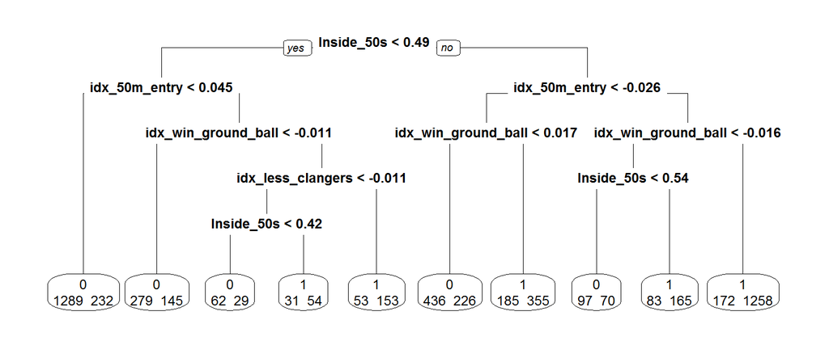

## ML: Model 2 - Tuned Decision Tree (cont'd)

### Model baseline assessment

Testing the tuned decision tree with 2017 data including player metrics, the below shows a marginal improvement in AUC but not much impact on the classification accuracy over the basic tree model.

```r
  table(test1$team_result, predict(tree2_V2, newdata = test1, type = "class"))
```

```
##
##       0   1
##   0 168  36
##   1  56 148
```

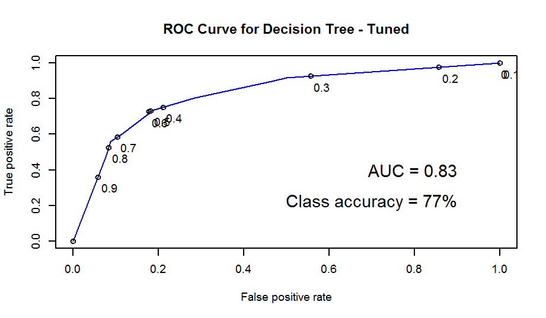

```r
  pred_tree2ROC = predict(tree2_V2, newdata = test1) # note: changing threshold to 0.6 did not improve results
  pred_tree2R = prediction(pred_tree2ROC[ ,2], test1$team_result)
  perf_tree2R = performance(pred_tree2R, "tpr", "fpr")
    par(cex = 0.6)
    plot(perf_tree2R, col="blue", main="ROC Curve for Decision Tree - Tuned", print.cutoffs.at = seq(0, 1, 0.1), text.adj = c(-0.2, 1.7))
    text(0.9, 0.4, labels = paste("AUC = ", round(as.numeric(performance(pred_tree2R, "auc")@y.values),2),sep=""), adj=1, cex = 1.5)
    text(0.9, 0.22, labels = paste("Class accuracy = ", round((168+148)/408,2)*100, "%", sep=""), adj=1, cex = 1.5)
```

## ML: Model 2 - Tuned Decision Tree (cont'd)

### Model prediction assessment

Redacting the 2017 player metrics, the tuned decision tree was marginally better than the basic decision tree at predicting 2017's match results with a classification accuracy of 64% and AUC of 0.63.

```r
  pred_tree2_2017 = predict(tree2_V2, newdata = AFL.matches.2017.pred.sum.1, type = "class")
  table(AFL.matches.2017.pred.sum.1$team_result, pred_tree2_2017)
```

```
##    pred_tree2_2017
##       0   1
##   0 136  74
##   1  73 131
```

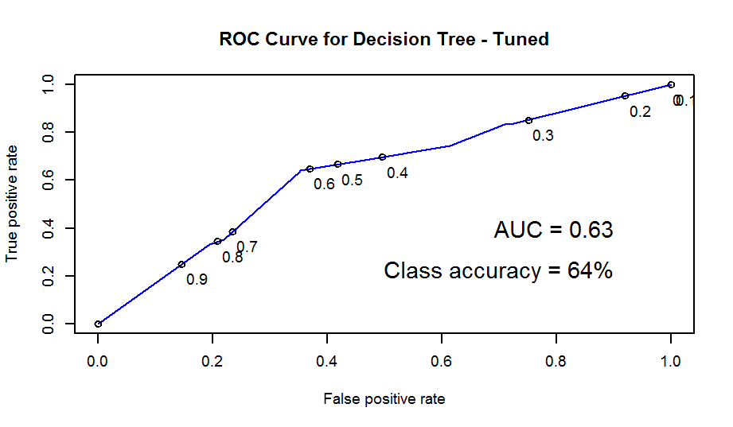

```r
  pred_tree2_2017pr = predict(tree2_V2, newdata = AFL.matches.2017.pred.sum.1)
  pred_tree2_2017ROC = prediction(pred_tree2_2017pr[ ,2], AFL.matches.2017.pred.sum.1$team_result)
  perf_tree2_2017ROC = performance(pred_tree2_2017ROC, "tpr", "fpr")
    par(cex = 0.6)
    plot(perf_tree2_2017ROC, col="blue", main="ROC Curve for Decision Tree - Tuned", print.cutoffs.at = seq(0, 1, 0.1), text.adj = c(-0.2, 1.7))
    text(0.9, 0.4, labels = paste("AUC = ", round(as.numeric(performance(pred_tree2_2017ROC, "auc")@y.values),2),sep=""), adj=1, cex = 1.5)
    text(0.9, 0.22, labels = paste("Class accuracy = ", round((136+131)/414,2)*100, "%", sep=""), adj=1, cex = 1.5)
```

## ML: Model 2 - Tuned Decision Tree (cont'd)

### Clustered model prediction assessment

The tuned decision trees for each of the six training clusters were created the same way as above, i.e. the ideal complexity parameter was determined and then adjusted to make results interpretable. This resulted in six models, one for each cluster. We'll assume a threshold of 0.5 for all clusters.

As before, I checked the classification accuracy of each cluster decision tree as well as AUC. Below is an example for cluster 1, followed by a summary of results for all clusters:

```r
  # find class accuracy
  table(pred2017_clust1$team_result, predict(tree_clust1, newdata = pred2017_clust1, type = "prob")[,2] > 0.5)
```

```
##
##     FALSE TRUE
##   0     9    0
##   1     0    2
```

```r
  # find AUC
  pred_tree_clust1_2017 = prediction(predict(tree_clust1, newdata = pred2017_clust1)[ ,2], pred2017_clust1$team_result)
  round(as.numeric(performance(pred_tree_clust1_2017, "auc")@y.values),2)
```

```
## [1] 1
```

| Cluster | Games | Class accuracy | AUC |
| --- | --- | --- | --- |
| 1 | 11 | 100% | 1.00 |
| 2 | 17 | 65% | 0.50 |
| 3 | 43 | 67% | 0.65 |
| 4 | 133 | 65% | 0.65 |
| 5 | 146 | 64% | 0.63 |
| 6 | 64 | 66% | 0.66 |

The weighted average class accuracy was 65% and AUC was 0.65, both marginally better than the non-clustered model.

## ML: Model 3 - Logistic Regression

### Creating a logistic regression model

A logistic regression model seeks a linear relationship in a classification problem. The following shows the output of a logistic regression using all variables.

```
##
## Call:
## glm(formula = team_result ~ Contested_marks + Clearances + Contested_possessions +
##     Clangers + idx_win_aerial_ball + Marks_inside_50 + idx_less_frees +
##     idx_win_ground_ball + idx_clear_ball + idx_less_clangers +
##     idx_50m_entry + Frees_against + Inside_50s, family = binomial,
##     data = train1)
##
## Deviance Residuals:
##     Min       1Q   Median       3Q      Max
## -2.8970  -0.6371   0.0000   0.6375   2.8968
##
## Coefficients:
##                       Estimate Std. Error z value Pr(>|z|)
## (Intercept)           -3.53410    0.65643  -5.384 7.29e-08 ***
## Contested_marks       -0.09635    0.59741  -0.161  0.87187
## Clearances             0.34658    0.54048   0.641  0.52136
## Contested_possessions -0.45603    0.47295  -0.964  0.33494
## Clangers               0.56499    0.55466   1.019  0.30837
## idx_win_aerial_ball    0.72563    0.26985   2.689  0.00717 **
## Marks_inside_50        0.60350    0.50034   1.206  0.22775
## idx_less_frees        -4.91245    0.45164 -10.877  < 2e-16 ***
## idx_win_ground_ball   15.31529    1.10466  13.864  < 2e-16 ***
## idx_clear_ball         0.58017    0.48929   1.186  0.23573
## idx_less_clangers      9.60434    0.75480  12.724  < 2e-16 ***
## idx_50m_entry          4.03112    0.27082  14.885  < 2e-16 ***
## Frees_against         -1.14265    0.61670  -1.853  0.06390 .
## Inside_50s             7.24881    0.39550  18.328  < 2e-16 ***
## ---
## Signif. codes:  0 '***' 0.001 '**' 0.01 '*' 0.05 '.' 0.1 ' ' 1
##
## (Dispersion parameter for binomial family taken to be 1)
##
##     Null deviance: 7449.9  on 5373  degrees of freedom
## Residual deviance: 4480.6  on 5360  degrees of freedom
## AIC: 4508.6
##
## Number of Fisher Scoring iterations: 5
```

## ML: Model 3 - Logistic Regression (cont'd)

I removed non-significant variables one at a time and did not find significant multicollinearity among the remaining variables. The remaining model represents the best linear relationship between training x variables explaining y, where all x variables are statistically significant. The below output has been tidied using the **broom** package.

```
##                  term   estimate std.error  statistic      p.value
## 1         (Intercept) -3.7024821 0.1930328 -19.180587 5.376952e-82
## 2 idx_win_aerial_ball  0.6103372 0.1742489   3.502674 4.606129e-04
## 3      idx_less_frees -4.3877527 0.3366227 -13.034632 7.774111e-39
## 4 idx_win_ground_ball 15.6620305 0.8361181  18.731841 2.723356e-78
## 5   idx_less_clangers  9.1791529 0.5693165  16.123111 1.755452e-58
## 6       idx_50m_entry  4.2322507 0.2110606  20.052300 1.927247e-89
## 7          Inside_50s  7.4055732 0.3788730  19.546319 4.433787e-85
```

```r
  cor(train1 %>% transmute(team_result = as.numeric(team_result), idx_win_aerial_ball, idx_less_frees, idx_win_ground_ball, idx_less_clangers, idx_50m_entry, Inside_50s))
```

```
##                     team_result idx_win_aerial_ball idx_less_frees idx_win_ground_ball idx_less_clangers idx_50m_entry Inside_50s
## team_result          1.00000000          0.32140675     0.05552328           0.4583269         0.2898967    0.40358602  0.4851361
## idx_win_aerial_ball  0.32140675          1.00000000     0.01395484           0.3734674         0.1200827    0.37386278  0.2386524
## idx_less_frees       0.05552328          0.01395484     1.00000000           0.2882767         0.5948194   -0.01779679  0.1228289
## idx_win_ground_ball  0.45832687          0.37346742     0.28827671           1.0000000         0.2308327    0.22431933  0.4783738
## idx_less_clangers    0.28989666          0.12008274     0.59481944           0.2308327         1.0000000    0.12797648  0.2797132
## idx_50m_entry        0.40358602          0.37386278    -0.01779679           0.2243193         0.1279765    1.00000000  0.2004159
## Inside_50s           0.48513615          0.23865244     0.12282893           0.4783738         0.2797132    0.20041592  1.0000000
```

## ML: Model 3 - Logistic Regression (cont'd)

### Model baseline assessment

Testing the logistic regression model with 2017 data including player metrics, the below shows another improvement in AUC but no real impact on the classification accuracy over both tree models. The ROC curve shows we could pick a threshold value of 0.4 or 0.6 to improve results but we'll stick with 0.5.

```r
  pred_log3 = predict(log3, type = "response", newdata = test1)
  table(test1$team_result, pred_log3 >= 0.5)
```

```
##
##     FALSE TRUE
##   0   158   46
##   1    46  158
```

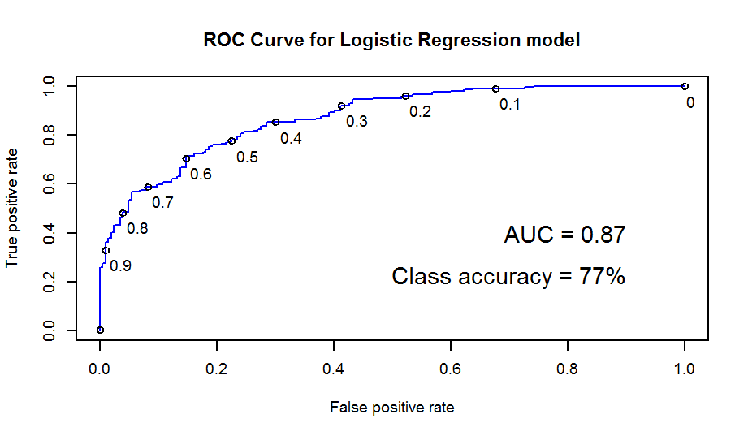

```r
  pred_log3R = prediction(pred_log3, test1$team_result)
  perf_log3R = performance(pred_log3R, "tpr", "fpr")
    par(cex = 0.6)
    plot(perf_log3R, col="blue", main="ROC Curve for Logistic Regression model", print.cutoffs.at = seq(0, 1, 0.1), text.adj = c(-0.2, 1.7))
    text(0.9, 0.4, labels = paste("AUC = ", round(as.numeric(performance(pred_log3R, "auc")@y.values),2),sep=""), adj=1, cex = 1.5)
    text(0.9, 0.22, labels = paste("Class accuracy = ", round(158/(158+46),2)*100, "%", sep=""), adj=1, cex = 1.5)
```

## ML: Model 3 - Logistic Regression (cont'd)

### Model prediction assessment

```r
  pred_log3_2017 = predict(log3, newdata = AFL.matches.2017.pred.sum.1, type = "response")
  table(AFL.matches.2017.pred.sum.1$team_result, pred_log3_2017 > 0.5)
```

```
##
##     FALSE TRUE
##   0   131   79
##   1    76  128
```

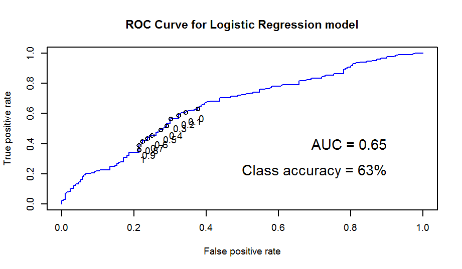

```r
  pred_log3_2017pr = predict(log3, newdata = AFL.matches.2017.pred.sum.1)
  pred_log3_2017ROC = prediction(pred_log3_2017pr, AFL.matches.2017.pred.sum.1$team_result)
  perf_log3_2017ROC = performance(pred_log3_2017ROC, "tpr", "fpr")
    par(cex = 0.6)
    plot(perf_log3_2017ROC, col="blue", main="ROC Curve for Logistic Regression model", print.cutoffs.at = seq(0, 1, 0.1), text.adj = c(-0.2, 1.7))
    text(0.9, 0.4, labels = paste("AUC = ", round(as.numeric(performance(pred_log3_2017ROC, "auc")@y.values),2),sep=""), adj=1, cex = 1.5)
    text(0.9, 0.22, labels = paste("Class accuracy = ", round((131+128)/414,2)*100, "%", sep=""), adj=1, cex = 1.5)
```

## ML: Model 3 - Logistic Regression (cont'd)

### Clustered model prediction assessment

The logistic regression models for each of the six training clusters were created the same way as above, i.e. non-significant predictor variables removed one by one until only significant variables remain, then checked for multicollinearity. We'll assume a threshold of 0.5 for all clusters.

As before, I checked the classification accuracy of each cluster regression model as well as AUC. Below is an example for cluster 1, followed by a summary of results for all clusters:

```r
  # find class accuracy
  pred_log_clust1_2017 = predict(log_clust1, type = "response", newdata = pred2017_clust1)
  table(pred2017_clust1$team_result, pred_log_clust1_2017 >= 0.5)
```

```
##
##     FALSE TRUE
##   0     9    0
##   1     1    1
```

```r
  # find AUC
  pred_log_clust1R_2017 = prediction(pred_log_clust1_2017, as.factor(pred2017_clust1$team_result))
  round(as.numeric(performance(pred_log_clust1R_2017, "auc")@y.values),2)
```

```
## [1] 0.94
```

| Cluster | Games | Class accuracy | AUC |
| --- | --- | --- | --- |
| 1 | 11 | 91% | 0.94 |
| 2 | 17 | 65% | 0.76 |
| 3 | 43 | 70% | 0.60 |
| 4 | 133 | 60% | 0.62 |
| 5 | 146 | 60% | 0.57 |
| 6 | 64 | 69% | 0.75 |

The weighted average class accuracy was 63% and AUC was 0.63, so no improvement on the non-clustered model.

## ML: Model 3 - Logistic Regression (cont'd)

### Model interpretation - variable significance

To uncover further insights, using the non-clustered logistic regression model I checked the relative importance of each variable by leaving out one at a time to measure the AUC lift provided by the variable. The table below summarises the results, which are a key conclusion for the analysis.

```r
  logx = glm(team_result ~ idx_win_aerial_ball + idx_less_frees + idx_win_ground_ball + idx_less_clangers + idx_50m_entry + Inside_50s,
             data = train1, family = binomial)
  pred_logxR = prediction(predict(logx, type = "response", newdata = test1), test1$team_result)
  as.numeric(performance(pred_logxR, "auc")@y.values)
```

| Variable | AUC lift | Ranking | Comment |
| --- | --- | --- | --- |
| idx_win_aerial_ball | -0.01 | Last | AUC went up without this variable, likely due to multicollinearity |
| idx_less_frees | +0.00 | 5th | Negligible impact to AUC |
| **idx_win_ground_ball** | **+0.03** | **2nd** | **Strong impact to AUC** |
| idx_less_clangers | +0.01 | =3rd | Some impact to AUC |
| **idx_50m_entry** | **+0.04** | **1st** | **Strong impact to AUC** |
| Inside_50s | +0.01 | =3rd | Some impact to AUC |

## Conclusions

## Findings

### Key indicators to winning AFL matches

This analysis demonstrated and confirmed long-held assumptions on how AFL matches are won. The two key measures teams should strive towards to win more matches are:

- Winning more of the ground ball in contested situations than the other team, and
- Being more accurate entering the forward 50m arc than the other team.

It also helps to have more contributors to entering the forward 50m arc generally, and to make less unforced mistakes than opponents. If I was a coach, during this off-season my focus would be on these factors as well as using data to recruit players with strong abilities in these areas.

### Predicting AFL match results

Data has a stronger than expected ability to predict match results, given the adversarial nature of sport. A well-tuned decision tree or logistic regression model does a reasonable job of "blind" predicting future match results when player metrics from the predicted season are redacted. Clustering also proved to be a potential method of boosting predictive accuracy for decision trees in particular.

## Opportunities for further analysis

### Increasing predictive accuracy further

To keep the analysis simple, I only performed clustering once using six clusters, and when testing model predictions I consistently kept a threshold value of 0.5. Adjusting either or both of these can have a decent impact to accuracy; for example, using the ROC Curve to choose the threshold boosted accuracy in some cases. However, for a true prediction we don't have access to the ROC Curve so we would need to be very confident in the chosen threshold value for a particular cluster.

Similarly, changing the number of clusters might improve accuracy but lose interpretability of results.

### Methodology for prediction

I used 2016 player metric means to predict 2017 match results; this is a very unsophisticated method of assuming the independent variables. I tried linear regression but this degraded results. So there is a clear opportunity to create smarter prediction models for the independent variables used to predict match results; for example, this could consider how a player's output normally changes over the course of their career, impact of injuries on long-term performance, how players fare against specific opponents or on specific grounds etc.

## Wrap up

Overall, this analysis is a great proof-of-concept of the insights which could be uncovered in AFL to gain a competitive advantage on the pitch. This project only used player metrics to predict team results, yet came up with stronger predictive capability than I thought was likely in sport. For a simple analysis on free data, it has been surprisingly insightful.

There is a huge amount of scope to improve the analysis:

- Using full Champion Data, including efficiency statistics and play-by-play analysis
- Combining player GPS tracker data to understand how running patterns and workrate interplay with efficiency and winning plays

This approach can also be applied to other sports.